# Income Disparity in High School Graduation Over Time

The goal of this project is to examine the family income disparity in high school graduation rate for students enrolled in North Carolina public schools over time. I downloaded the data from [NC PDI](https://www.dpi.nc.gov/districts-schools/testing-and-school-accountability/school-accountability-and-reporting/cohort-graduation-rates#4-YearCohortGraduationRates-883).

The formula to calculate the graduation rate is listed as following,
$$\begin{aligned}
high\ school\ graduation\ rate = \frac{Total\ number\ of\
graduates}{Total\ number\ of\ HS\ 12th\ graders}
\end{aligned}$$

Here is a table showing North Carolina graduation rates across family income groups by year.

|  | reporting_year | num_students | graduate_pct | subgroup | num_gradu |
| --- | --- | --- | --- | --- | --- |
| 1 | 2006 | 8162 | 55.6 | EDS | 4538 |
| 2 | 2006 | 104606 | 68.3 | ALL | 71446 |
| 3 | 2007 | 29256 | 66 | EDS | 19309 |
| 4 | 2007 | 105799 | 69.5 | ALL | 73530 |
| 5 | 2008 | 34616 | 59.2 | EDS | 20493 |
| 6 | 2008 | 108852 | 70.3 | ALL | 76523 |
| 7 | 2009 | 38833 | 61.8 | EDS | 23999 |
| 8 | 2009 | 113471 | 71.8 | ALL | 81472 |
| 9 | 2010 | 43170 | 66.2 | EDS | 28579 |
| 10 | 2010 | 112299 | 74.2 | ALL | 83326 |

[output cut: 28 more lines]

I plot a graph to show the graduation rate change over time across economically disadvantaged status groups.

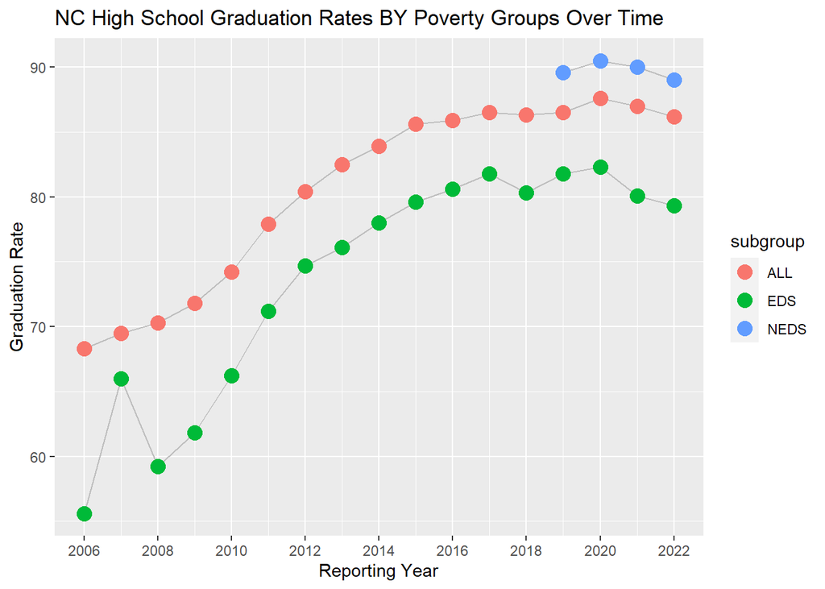

```r
# go to https://github.com/rstudio/cheatsheets/blob/main/data-visualization.pdf
g <- ggplot(data=df.nc.all, aes(x=reporting_year, y=graduate_pct, group=subgroup, color=subgroup))

g + geom_line( color="grey") +
    geom_point(size=4) +
    ggtitle("NC High School Graduation Rates BY Poverty Groups Over Time") +
    xlab("Reporting Year") +
    ylab("Graduation Rate") +
    scale_x_continuous(breaks=seq(2006,2022,by=2))
```

## Findings

The poverty effect on high school graduation rates for students enrolled in North Carolina public schools has been significant over time. Data has shown that students from economically disadvantaged students (EDS) tend to have lower graduation rates compared to their non economically disadvantaged student (NEDS) peers.

## Discussion

This is likely due to a variety of factors, including lack of access to resources such as quality education, nutrition, and healthcare, as well as societal and cultural barriers.

Students from low-income families may also face additional stressors and challenges outside of school that can impact their ability to focus on their education. These economic disadvantages can have a cumulative effect on academic achievement, leading to lower graduation rates among students living in poverty.

It is important for schools and policymakers to address these issues and work towards providing more resources and support for low-income students to help improve their graduation rates.